# Aula 9: Estrutura de Repetição FOR

# Estrutura de Repetição FOR

Nesta aula, vamos abordar as estruturas de repetição, com foco no loop `FOR`. As estruturas de repetição permitem executar instruções repetidamente até que uma condição seja atingida, o que é fundamental para a automação de tarefas repetitivas no R.

## Estruturas de Controle vs. Estruturas de Repetição

### Estruturas de Controle

As estruturas de controle permitem a execução condicional ou seletiva de instruções com base em condições que são testadas. As estruturas mais comuns são: - **`if-else`**: Executa blocos de código com base em uma condição. - **`switch`** ou **`cases`**: Escolhe uma ação a ser executada com base no valor de uma expressão.

### Estruturas de Repetição

As estruturas de repetição, também conhecidas como loops ou estruturas de iteração, permitem a execução repetida de instruções até que uma condição seja satisfeita. Os tipos mais comuns são: - **`FOR` ou `FOREACH`**: Usado para executar instruções um número conhecido de vezes. - **`WHILE`**: Continua a execução enquanto uma condição for verdadeira. - **`REPEAT` ou `DO-UNTIL`**: Repete a execução até que uma condição seja satisfeita.

Enquanto as estruturas de controle permitem desvios no fluxo de execução com base em condições, as estruturas de repetição avaliam uma condição e executam o código iterativamente até que a condição mude.

## Estrutura de Loop FOR

O loop `FOR` é usado para executar instruções um número previamente **conhecido** de vezes. Por exemplo: - Percorrer um vetor e executar uma ação específica para cada elemento. - Executar um bloco de código para cada valor em uma sequência de números.

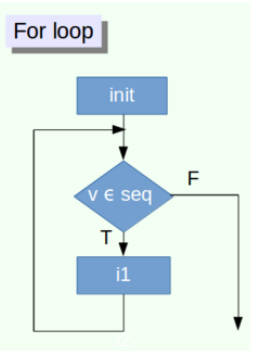

O loop `FOR` itera sobre uma sequência de valores, que pode ser um vetor, lista, ou qualquer objeto que possua uma sequência. O loop pode ser interrompido ou saltado conforme condições específicas.

### Sintaxe Básica

A estrutura básica de um loop `FOR` em R é a seguinte:

```r
for (variavel in vetor) {
  # Código a ser executado em cada iteração
}
```

- **`variavel`**: É a variável indexadora que assume cada valor dentro do vetor conforme o loop avança.
- **`vetor`**: É o conjunto de valores sobre os quais o loop irá iterar.

### Exemplo: Estrutura `FOR` com `next` e `break`

Vamos criar um exemplo em que utilizamos o `next` para pular uma iteração e o `break` para interromper o loop antes que ele seja concluído.

```r
for (i in 1:10) {
  if (i == 5) {
    next  # Pula a iteração quando i é 5
  }
  if (i == 8) {
    break  # Interrompe o loop quando i é 8
  }
  print(i)
}
```

```
[1] 1
[1] 2
[1] 3
[1] 4
[1] 6
[1] 7
```

### Exemplo Prático: Calculando Rendimentos com Juros Compostos

Neste exemplo, vamos calcular o rendimento de um investimento ao longo de 12 meses, com uma taxa de juros fixa. A cada mês, o valor do investimento é atualizado com base na taxa de juros.

```r
taxa <- 0.01  # Taxa de juros de 1%
meses <- 12   # Período de 12 meses
rendimento <- numeric(meses)  # Vetor para armazenar os rendimentos

rendimento[1] <- 1000  # Investimento inicial

for (i in 2:meses) {
  rendimento[i] <- rendimento[i-1] * (1 + taxa)
  print(rendimento[i])
}
```

```
[1] 1010
[1] 1020.1
[1] 1030.301
[1] 1040.604
[1] 1051.01
[1] 1061.52
[1] 1072.135
[1] 1082.857
[1] 1093.685
[1] 1104.622
[1] 1115.668
```

```r
rendimento  # Exibe o rendimento acumulado ao longo dos meses
```

```
 [1] 1000.000 1010.000 1020.100 1030.301 1040.604 1051.010 1061.520 1072.135 1082.857 1093.685
[11] 1104.622 1115.668
```

### Exemplo Prático: Sequência de Fibonacci

A sequência de Fibonacci é uma série de números em que cada número é a soma dos dois anteriores. Vamos calcular os 50 primeiros números da sequência utilizando um loop `FOR`.

```r
n <- 50
fibonacci <- numeric(n)
fibonacci[1] <- 1
fibonacci[2] <- 1

for (i in 3:n) {
  fibonacci[i] <- fibonacci[i - 1] + fibonacci[i - 2]
}

fibonacci  # Exibe os 50 primeiros números da sequência de Fibonacci
```

[output not shown]

### Exemplo Prático: Simulação de Investimento com Variação de Juros

Vamos simular o crescimento de um investimento inicial de R$100,00 ao longo de 9 meses, com diferentes taxas de juros aplicadas a cada mês. Vamos usar um loop `FOR` para calcular o valor final do investimento.

```r
investimento <- 100  # Valor inicial do investimento
juros <- c(0.043, 0.034, 0.049, 0.062, 0.055, 0.047, 0.057, 0.049, 0.048)

for (j in juros) {
  investimento <- investimento * (1 + j)
  cat("Taxa de juros do mês:", j, "\t Valor final:", investimento, "\n")
}

investimento  # Valor final do investimento após 9 meses
```

[output not shown]

### Explicação do Exemplo de Juros

Neste exemplo, o loop `FOR` percorre o vetor `juros`, que contém as taxas de juros mensais. Para cada mês, o valor do investimento é atualizado com base na taxa de juros daquele mês, e o resultado é exibido na tela. No final, o valor total do investimento é retornado.

## Conclusão

Nesta aula, abordamos a estrutura de repetição `FOR`, uma das mais utilizadas para executar um bloco de código várias vezes. Vimos exemplos práticos como a sequência de Fibonacci e o cálculo de rendimentos, demonstrando como o `FOR` pode ser aplicado a diferentes situações no R. As estruturas de repetição são ferramentas essenciais para automatizar tarefas e realizar cálculos iterativos em grandes conjuntos de dados.